# Data624 - Project 1

Esteban Aramayo, Coffy Andrews-Guo, LeTicia Cancel, Joseph Connolly, Ian Costello

2022-06-21

Required Libraries

```r
library(readxl)
library(tidyverse)
library(ggplot2)
library(patchwork)
library(fpp2)
library(caret)
library(RANN)
library(VIM)
library(ggpubr)
library(gridExtra)
library(forecast)
library(writexl)
```

# Project Summary

In this project for Data 624, Predictive Modeling, we were provided seemingly random, non-descript data to which we had to conduct a series of 6 forecasts of various pairs of variables.

```r
df <- read_excel("data.xls")
head(df)
```

```
#> # A tibble: 6 x 7
#>   SeriesInd category Var01     Var02 Var03 Var05 Var07
#>       <dbl> <chr>    <dbl>     <dbl> <dbl> <dbl> <dbl>
#> 1     40669 S03       30.6 123432400  30.3  30.5  30.6
#> 2     40669 S02       10.3  60855800  10.0  10.2  10.3
#> 3     40669 S01       26.6  10369300  25.9  26.2  26.0
#> 4     40669 S06       27.5  39335700  26.8  27.0  27.3
#> 5     40669 S05       69.3  27809100  68.2  68.7  69.2
#> 6     40669 S04       17.2  16587400  16.9  16.9  17.1
```

The data set does not appear to have any distinguishing labels that would indicate anything about the source nor recordings of the data set. Under normal circumstances, context about data and use case would be known and provided, as this is important for forecasting. Context can help identify appropriate methods and models that would be best suited to produce an accurate result. This follows the “no free lunch” principle, which states that in machine learning there is no best algorithm that can be used to solve all problems. Regardless, this dataset is completely for practice and exercising forecasting in an academic setting.

## Data Cleaning & Imputation

```r
# Factoring category to get a count of the elements within dataset
df$category <- as.factor(df$category)


summary(df)
```

```
#>    SeriesInd     category       Var01            Var02
#>  Min.   :40669   S01:1762   Min.   :  9.03   Min.   :  1339900
#>  1st Qu.:41303   S02:1762   1st Qu.: 23.10   1st Qu.: 12520675
#>  Median :41946   S03:1762   Median : 38.44   Median : 21086550
#>  Mean   :41945   S04:1762   Mean   : 46.98   Mean   : 37035741
#>  3rd Qu.:42587   S05:1762   3rd Qu.: 66.78   3rd Qu.: 42486700
#>  Max.   :43221   S06:1762   Max.   :195.18   Max.   :480879500
#>                             NA's   :854      NA's   :842
#>      Var03            Var05            Var07
#>  Min.   :  8.82   Min.   :  8.99   Min.   :  8.92
#>  1st Qu.: 22.59   1st Qu.: 22.91   1st Qu.: 22.88
#>  Median : 37.66   Median : 38.05   Median : 38.05
#>  Mean   : 46.12   Mean   : 46.55   Mean   : 46.56
#>  3rd Qu.: 65.88   3rd Qu.: 66.38   3rd Qu.: 66.31
#>  Max.   :189.36   Max.   :195.00   Max.   :189.72
#>  NA's   :866      NA's   :866      NA's   :866
```

```r
writeLines("\n\n")
```

```r
str(df)
```

```
#> tibble [10,572 x 7] (S3: tbl_df/tbl/data.frame)
#>  $ SeriesInd: num [1:10572] 40669 40669 40669 40669 40669 ...
#>  $ category : Factor w/ 6 levels "S01","S02","S03",..: 3 2 1 6 5 4 3 2 1 6 ...
#>  $ Var01    : num [1:10572] 30.6 10.3 26.6 27.5 69.3 ...
#>  $ Var02    : num [1:10572] 1.23e+08 6.09e+07 1.04e+07 3.93e+07 2.78e+07 ...
#>  $ Var03    : num [1:10572] 30.3 10.1 25.9 26.8 68.2 ...
#>  $ Var05    : num [1:10572] 30.5 10.2 26.2 27 68.7 ...
#>  $ Var07    : num [1:10572] 30.6 10.3 26 27.3 69.2 ...
```

#### Data Structure

```r
# md

str(df)
```

```
#> tibble [10,572 x 7] (S3: tbl_df/tbl/data.frame)
#>  $ SeriesInd: num [1:10572] 40669 40669 40669 40669 40669 ...
#>  $ category : Factor w/ 6 levels "S01","S02","S03",..: 3 2 1 6 5 4 3 2 1 6 ...
#>  $ Var01    : num [1:10572] 30.6 10.3 26.6 27.5 69.3 ...
#>  $ Var02    : num [1:10572] 1.23e+08 6.09e+07 1.04e+07 3.93e+07 2.78e+07 ...
#>  $ Var03    : num [1:10572] 30.3 10.1 25.9 26.8 68.2 ...
#>  $ Var05    : num [1:10572] 30.5 10.2 26.2 27 68.7 ...
#>  $ Var07    : num [1:10572] 30.6 10.3 26 27.3 69.2 ...
```

## Data Exploration

```r
#MD
dim(df)
```

```
#> [1] 10572     7
```

```r
#md
summary(df)
```

```
#>    SeriesInd     category       Var01            Var02
#>  Min.   :40669   S01:1762   Min.   :  9.03   Min.   :  1339900
#>  1st Qu.:41303   S02:1762   1st Qu.: 23.10   1st Qu.: 12520675
#>  Median :41946   S03:1762   Median : 38.44   Median : 21086550
#>  Mean   :41945   S04:1762   Mean   : 46.98   Mean   : 37035741
#>  3rd Qu.:42587   S05:1762   3rd Qu.: 66.78   3rd Qu.: 42486700
#>  Max.   :43221   S06:1762   Max.   :195.18   Max.   :480879500
#>                             NA's   :854      NA's   :842
#>      Var03            Var05            Var07
#>  Min.   :  8.82   Min.   :  8.99   Min.   :  8.92
#>  1st Qu.: 22.59   1st Qu.: 22.91   1st Qu.: 22.88
#>  Median : 37.66   Median : 38.05   Median : 38.05
#>  Mean   : 46.12   Mean   : 46.55   Mean   : 46.56
#>  3rd Qu.: 65.88   3rd Qu.: 66.38   3rd Qu.: 66.31
#>  Max.   :189.36   Max.   :195.00   Max.   :189.72
#>  NA's   :866      NA's   :866      NA's   :866
```

##### Handling Missing Data: Impute or Delete?

```r
paste0(sum(is.na(df))," values missing from original set")
```

```
#> [1] "4294 values missing from original set"
```

Looking at the summary generated above, columns 3-7 each have a range of 842-866 missing values, which sums to a total of 4,294 values. The dilemma is to decide whether or not it is appropriate to impute missing data, or to simply delete them. According to the plot below, generated via “VIM::aggr()”, 91.81% of the data is fulfilled. Var01, Var02, Var03, Var05, and Var07 are missing about 8% of data. This seems like an insignificant amount of data that can easily be omitted from the set. Further investigation is needed to determine the next appropriate steps.

An excerpt from the following paper, $\underline{The\ prevention\ and\ handling\ of\ the\ missing\ data}$, by Hyun Kang, argues when deletion is appropriate or not from the following quote: *“…if the assumption of MCAR (missing completely at random) is satisfied, a listwise deletion is known to produce unbiased estimates and conservative results. When the data do not fulfill the assumption of MCAR, listwise deletion may cause bias in the estimates of the parameters. If there is a large enough sample, where power is not an issue, and the assumption of MCAR is satisfied, the listwise deletion may be a reasonable strategy. However, when there is not a large sample, or the assumption of MCAR is not satisfied, the listwise deletion is not the optimal strategy”* [$^1$](https://www.ncbi.nlm.nih.gov/pmc/articles/PMC3668100/). By creating a shadow matrix to see a percentage (on a 0-1 scale) of missing values when all correlated among each other, this will help indicate whether or not the data is MCAR. [$^2$](https://stats.stackexchange.com/questions/172316/a-statistical-approach-to-determine-if-data-are-missing-at-random)

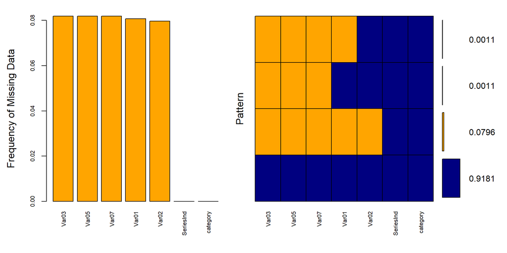

```
#>
#>  Variables sorted by number of missings:
#>   Variable      Count
#>      Var03 0.08191449
#>      Var05 0.08191449
#>      Var07 0.08191449
#>      Var01 0.08077942
#>      Var02 0.07964434
#>  SeriesInd 0.00000000
#>   category 0.00000000
```

```r
# Plots of missing values

aggr_plot <- VIM::aggr(df, col = c("navyblue", "orange"),
                  numbers = T, sortVars = T,
                  labels = names(df),
                  cex.axis = 0.7, gap = 3,
                  ylab = c("Frequency of Missing Data", "Pattern"))
```

```r
# Shadow Matrix: correlation of missing values from the dataset

x <- as.data.frame(abs(is.na(df)))

y <- x[which(sapply(x, sd) >0)] # Extracts which variables are missing/NA from the dataset

cor(y) # Tendency of NA when correlated among variables
```

```
#>           Var01     Var02     Var03     Var05     Var07
#> Var01 1.0000000 0.9923369 0.9924341 0.9924341 0.9924341
#> Var02 0.9923369 1.0000000 0.9848290 0.9848290 0.9848290
#> Var03 0.9924341 0.9848290 1.0000000 1.0000000 1.0000000
#> Var05 0.9924341 0.9848290 1.0000000 1.0000000 1.0000000
#> Var07 0.9924341 0.9848290 1.0000000 1.0000000 1.0000000
```

Taking these observations into consideration, it seems there appears to be bias in the data in the context of missing values. Therefore, the data is not missing completely at random, and an imputation is the appropriate step to take.

##### Data Imputation & Time Conversion

As stated, since the missing values are not MCAR, imputation will be utilized to represent missing values in our data set. There are numerous methods to impute data, especially in R. Within the caret package, the “preProcess()” function enables imputation and allows for users to select a method of imputation. The method “medianImpute” was chosen because of the ease and efficiency when handeling the data. This will replace all missing values with the median of a particular variable. After imputation, there are no longer any missing values. The data has also not been altered in a significant way which would compromise the integrity of the data as seen in the summary below.

```r
# Imputation via "medianImpute" method within "preProcess()" function via the caret package

preProcess_NAdata_model <- preProcess(as.data.frame(df), method ="medianImpute")

df <- predict(preProcess_NAdata_model, newdata = df)

paste0(sum(is.na(df))," values missing after imputation")
```

```
#> [1] "0 values missing after imputation"
```

```r
summary(df)
```

```
#>    SeriesInd     category       Var01            Var02
#>  Min.   :40669   S01:1762   Min.   :  9.03   Min.   :  1339900
#>  1st Qu.:41303   S02:1762   1st Qu.: 25.40   1st Qu.: 13073675
#>  Median :41946   S03:1762   Median : 38.44   Median : 21086550
#>  Mean   :41945   S04:1762   Mean   : 46.29   Mean   : 35765478
#>  3rd Qu.:42587   S05:1762   3rd Qu.: 61.34   3rd Qu.: 39322325
#>  Max.   :43221   S06:1762   Max.   :195.18   Max.   :480879500
#>      Var03            Var05            Var07
#>  Min.   :  8.82   Min.   :  8.99   Min.   :  8.92
#>  1st Qu.: 24.65   1st Qu.: 25.05   1st Qu.: 24.99
#>  Median : 37.66   Median : 38.05   Median : 38.05
#>  Mean   : 45.42   Mean   : 45.86   Mean   : 45.86
#>  3rd Qu.: 60.30   3rd Qu.: 60.83   3rd Qu.: 60.89
#>  Max.   :189.36   Max.   :195.00   Max.   :189.72
```

```r
# Converting Var02 to Datetime
#md, move the other timeseries here to replace
# be careful of the "Datetime" variable change, as it's used later on
df$SeriesInd <- as.integer(df$SeriesInd)


# Originally we used this conversion for dates
# df$SeriesInd <- as.POSIXct(df$SeriesInd, origin = "1970-01-01")

# Now let's try this new conversion
df$SeriesInd <- as.Date(df$SeriesInd, origin = "1899-12-30")




# Renaming SeriesInd to Date to clarify purpose

df <- df %>% rename("Datetime" = SeriesInd)
summary(df)
```

```
#>     Datetime          category       Var01            Var02
#>  Min.   :2011-05-06   S01:1762   Min.   :  9.03   Min.   :  1339900
#>  1st Qu.:2013-01-29   S02:1762   1st Qu.: 25.40   1st Qu.: 13073675
#>  Median :2014-11-03   S03:1762   Median : 38.44   Median : 21086550
#>  Mean   :2014-11-01   S04:1762   Mean   : 46.29   Mean   : 35765478
#>  3rd Qu.:2016-08-05   S05:1762   3rd Qu.: 61.34   3rd Qu.: 39322325
#>  Max.   :2018-05-01   S06:1762   Max.   :195.18   Max.   :480879500
#>      Var03            Var05            Var07
#>  Min.   :  8.82   Min.   :  8.99   Min.   :  8.92
#>  1st Qu.: 24.65   1st Qu.: 25.05   1st Qu.: 24.99
#>  Median : 37.66   Median : 38.05   Median : 38.05
#>  Mean   : 45.42   Mean   : 45.86   Mean   : 45.86
#>  3rd Qu.: 60.30   3rd Qu.: 60.83   3rd Qu.: 60.89
#>  Max.   :189.36   Max.   :195.00   Max.   :189.72
```

##### Final susbets

```r
# For forecasting later on
#md

# s01 <- df %>% filter(category == "S01")
# s02 <- df %>% filter(category == "S02")
# s03 <- df %>% filter(category == "S03")
# s04 <- df %>% filter(category == "S04")
# s05 <- df %>% filter(category == "S05")
# s06 <- df %>% filter(category == "S06")



#new subsets with data conversion
s01_2 <- df %>% filter(category == "S01")
s02_2 <- df %>% filter(category == "S02")
s03_2 <- df %>% filter(category == "S03")
s04_2 <- df %>% filter(category == "S04")
s05_2 <- df %>% filter(category == "S05")
s06_2 <- df %>% filter(category == "S06")
```

Create time series for each subset using the dataframe with dates

```r
# s01_ts <- ts(s01_2[,c("Var01","Var02")], frequency = 12, start = c(2011, 5), end = c(2018, 5))
# s02_ts <- ts(s02_2[,c("Var02","Var03")], frequency = 12, start = c(2011, 5), end = c(2018, 5))
# s03_ts <- ts(s03_2[,c("Var05","Var07")], frequency = 12, start = c(2011, 5), end = c(2018, 5))
# s04_ts <- ts(s04_2[,c("Var01","Var02")], frequency = 12, start = c(2011, 5), end = c(2018, 5))
# s05_ts <- ts(s05_2[,c("Var02","Var03")], frequency = 12, start = c(2011, 5), end = c(2018, 5))
# s06_ts <- ts(s06_2[,c("Var05","Var07")], frequency = 12, start = c(2011, 5), end = c(2018, 5))


first_year_days <- as.numeric(as.Date("2011-05-06") - as.Date("2011-01-01"))
last_year_days  <- as.numeric(as.Date("2018-05-01") - as.Date("2018-01-01"))


s01_ts <- ts(s01_2[,c("Var01","Var02")], frequency = 365, start = c(2011, first_year_days), end = c(2018, last_year_days))
s02_ts <- ts(s02_2[,c("Var02","Var03")], frequency = 365, start = c(2011, first_year_days), end = c(2018, last_year_days))
s03_ts <- ts(s03_2[,c("Var05","Var07")], frequency = 365, start = c(2011, first_year_days), end = c(2018, last_year_days))
s04_ts <- ts(s04_2[,c("Var01","Var02")], frequency = 365, start = c(2011, first_year_days), end = c(2018, last_year_days))
s05_ts <- ts(s05_2[,c("Var02","Var03")], frequency = 365, start = c(2011, first_year_days), end = c(2018, last_year_days))
s06_ts <- ts(s06_2[,c("Var05","Var07")], frequency = 365, start = c(2011, first_year_days), end = c(2018, last_year_days))
```

## Time series analysis

### Decomposition

Let’s use classical decomposition to investigate the trend, seasonal, and random components of each series.

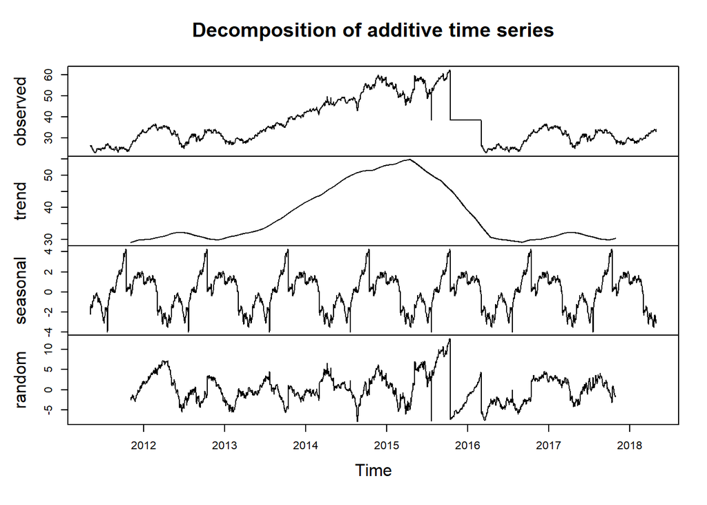

```r
# S01: Var01 & Var02
par(mfrow = c(2, 1))
plot(decompose(s01_ts[,1]))
```

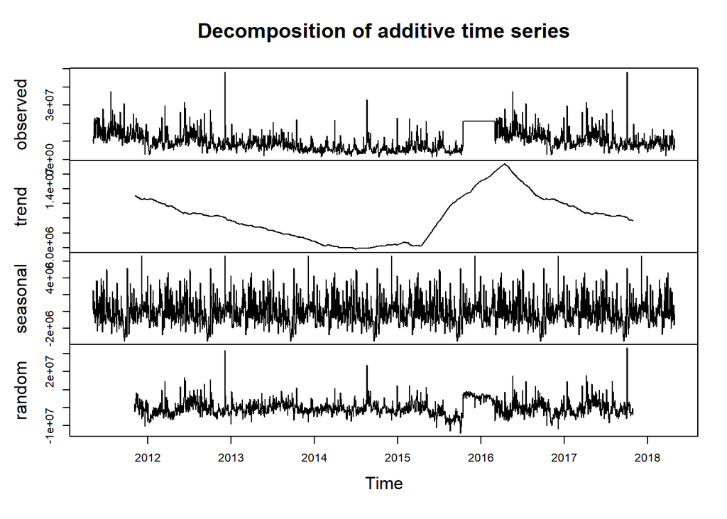

```r
plot(decompose(s01_ts[,2]))
```

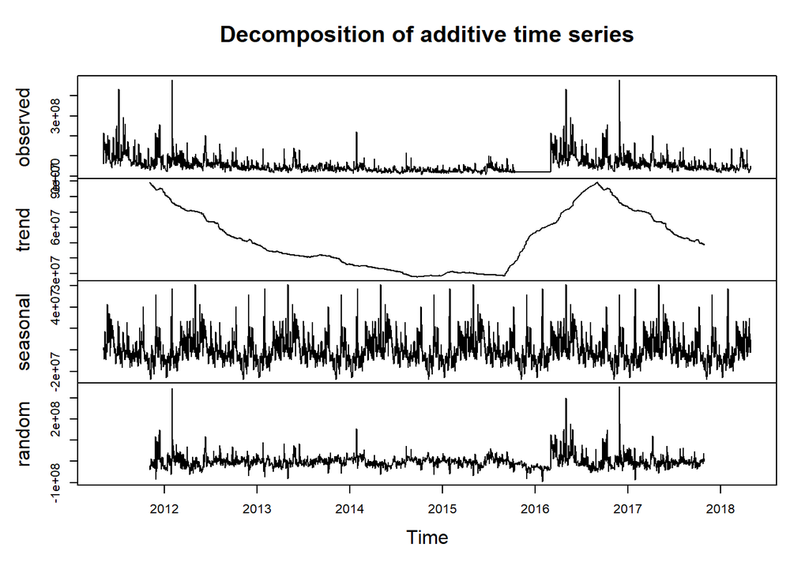

```r
# S02: Var02 & Var03
plot(decompose(s02_ts[,1]))
```

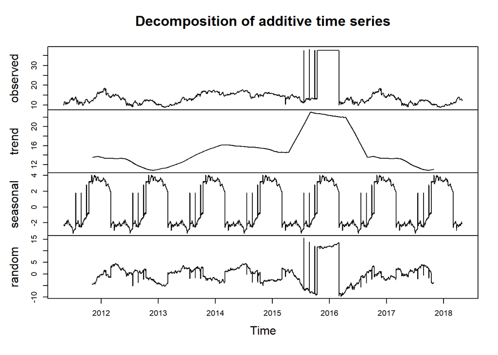

```r
plot(decompose(s02_ts[,2]))
```

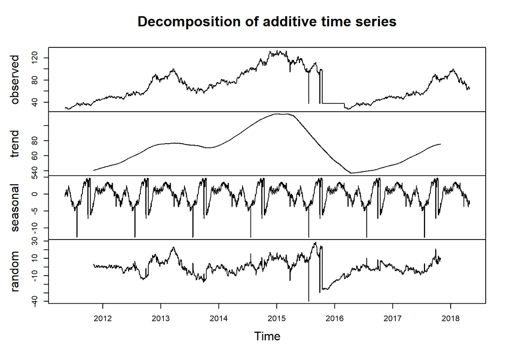

```r
# S03: Var05 & Var07
plot(decompose(s03_ts[,1]))
```

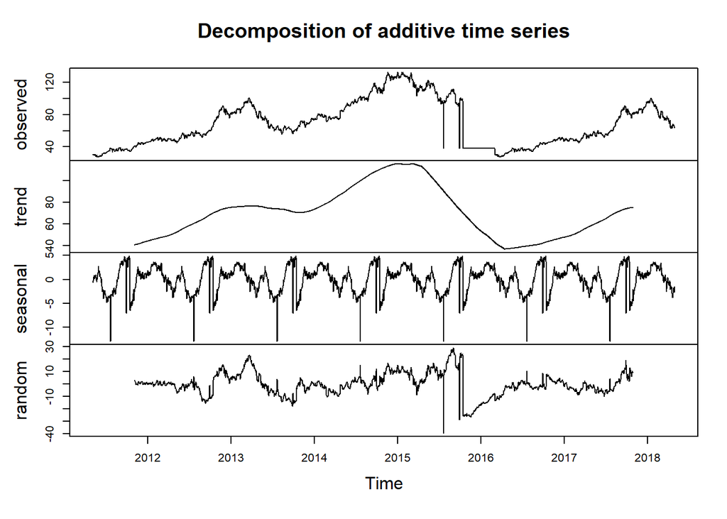

```r
plot(decompose(s03_ts[,2]))
```

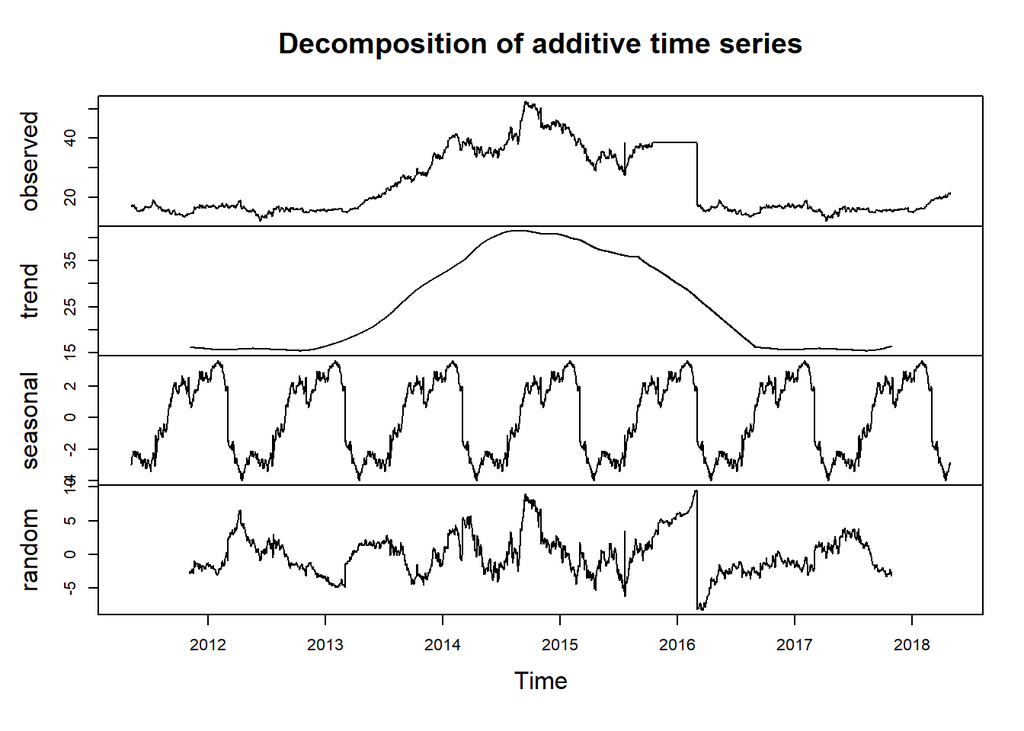

```r
# S04: Var01 & Var02
plot(decompose(s04_ts[,1]))
```

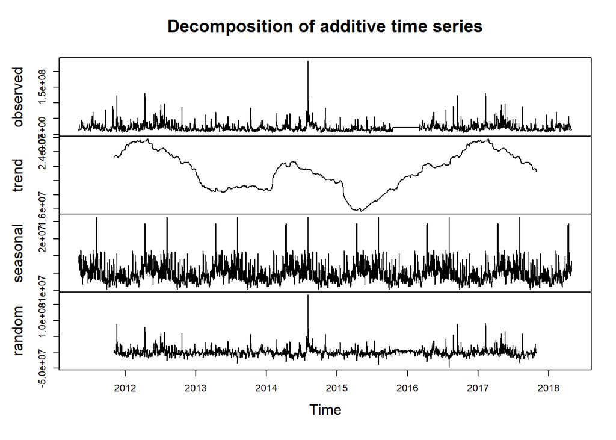

```r
plot(decompose(s04_ts[,2]))
```

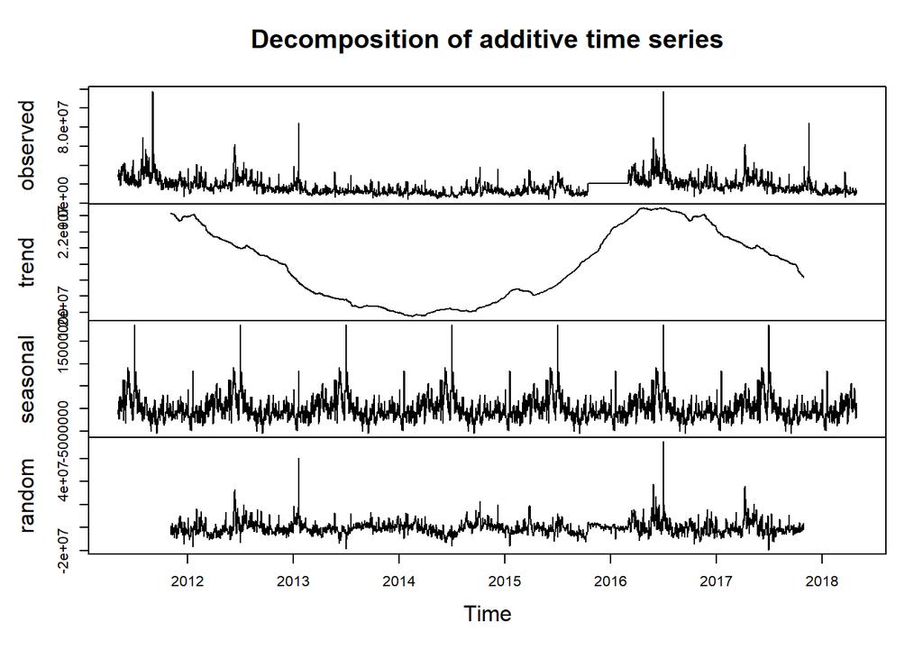

```r
# S05: Var02 & Var03
plot(decompose(s05_ts[,1]))
```

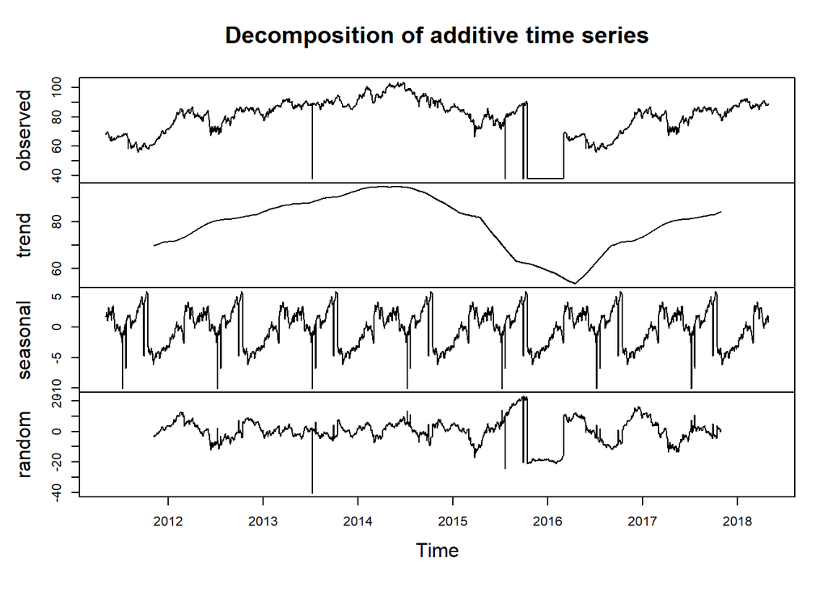

```r
plot(decompose(s05_ts[,2]))
```

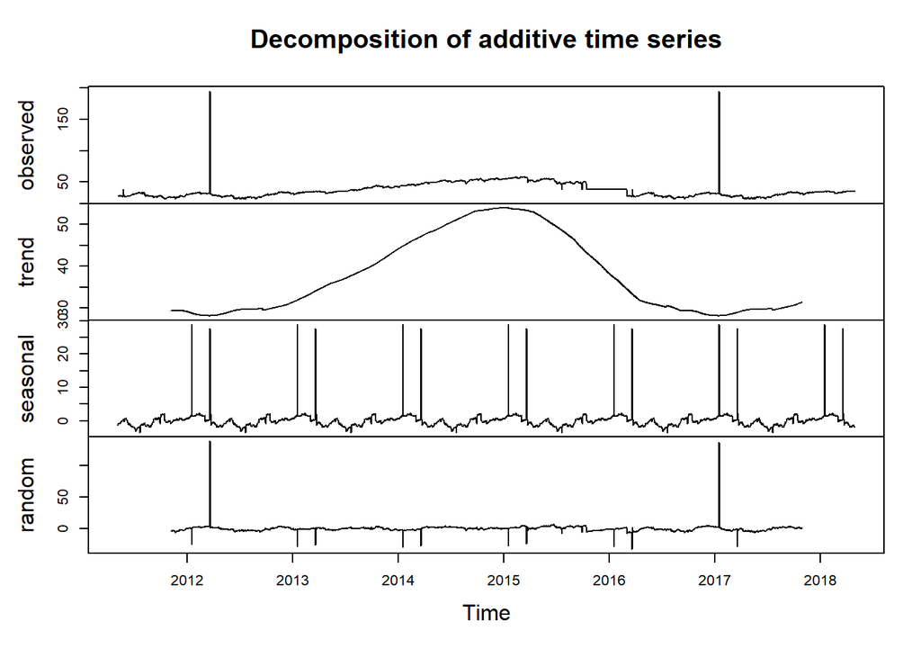

```r
# S06: Var05 & Var07
plot(decompose(s06_ts[,1]))
```

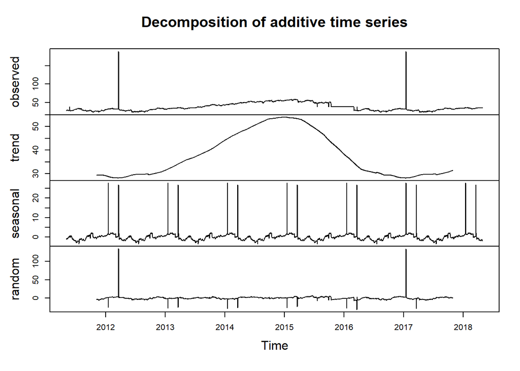

```r
plot(decompose(s06_ts[,2]))
```

### Differencing

Since all the series appear to have seasonality and some of them have trends, we will need to apply **differencing** to try to make the series stationary.

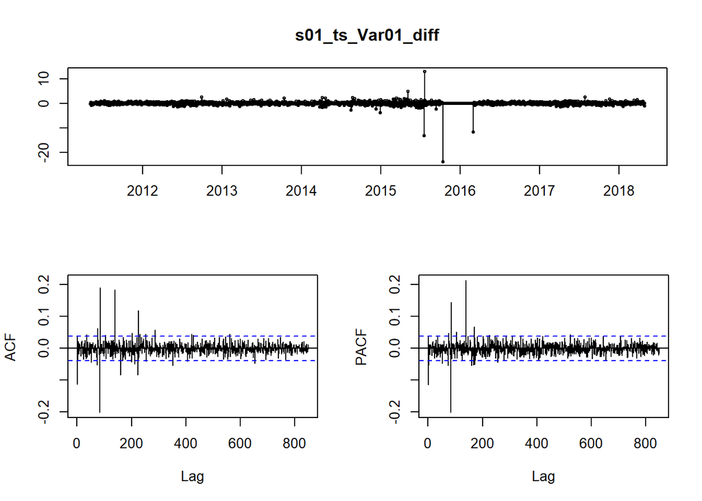

```r
# S01: Var01 & Var02
par(mfrow = c(1, 2))

s01_ts_Var01_diff <- diff(s01_ts[,1])
s01_ts_Var02_diff <- diff(s01_ts[,2])

tsdisplay(s01_ts_Var01_diff)
```

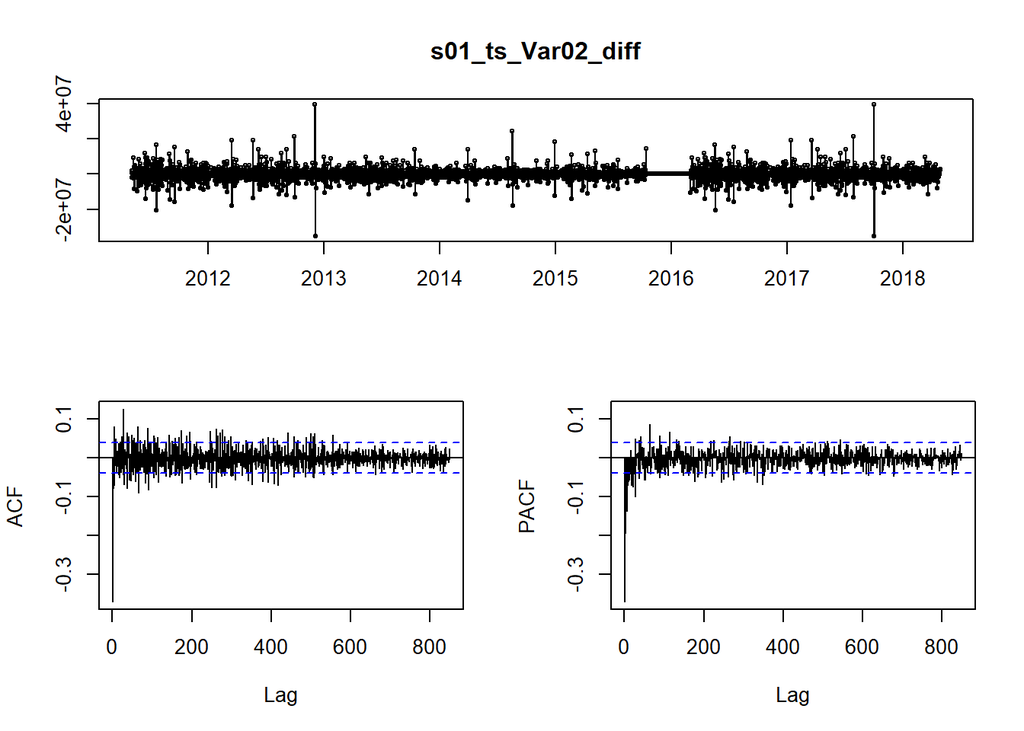

```r
tsdisplay(s01_ts_Var02_diff)
```

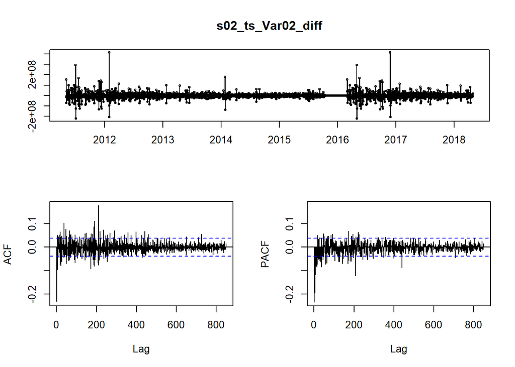

```r
# S02: Var02 & Var03

par(mfrow = c(1, 2))

s02_ts_Var02_diff <- diff(s02_ts[,1])
s02_ts_Var03_diff <- diff(s02_ts[,2])

tsdisplay(s02_ts_Var02_diff)
```

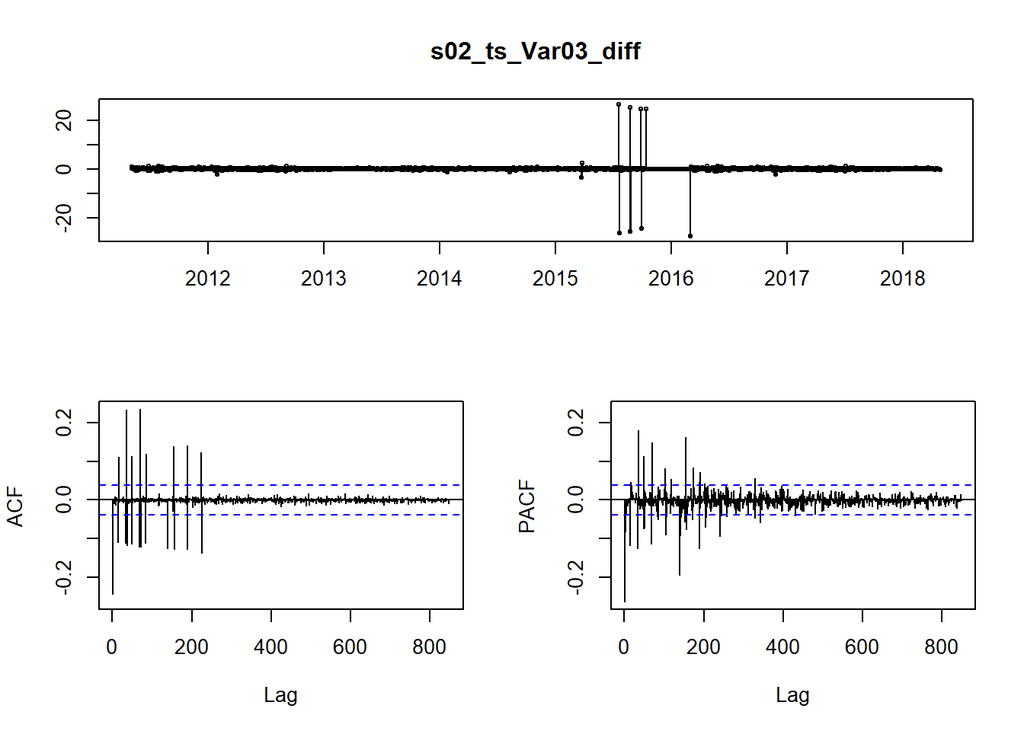

```r
tsdisplay(s02_ts_Var03_diff)
```

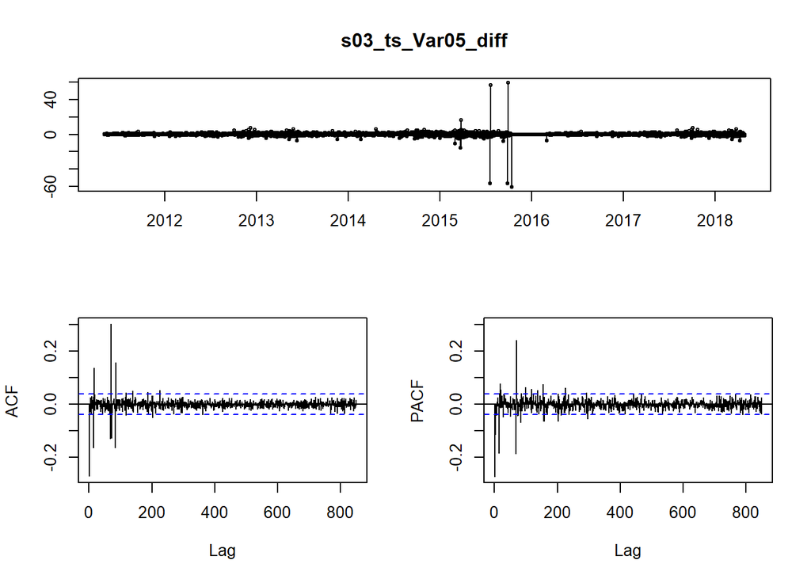

```r
# S03: Var05 & Var07

par(mfrow = c(1, 2))

s03_ts_Var05_diff <- diff(s03_ts[,1])
s03_ts_Var07_diff <- diff(s03_ts[,2])

tsdisplay(s03_ts_Var05_diff)
```

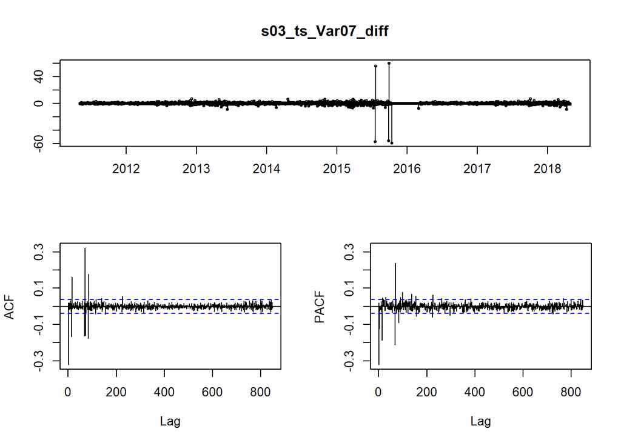

```r
tsdisplay(s03_ts_Var07_diff)
```

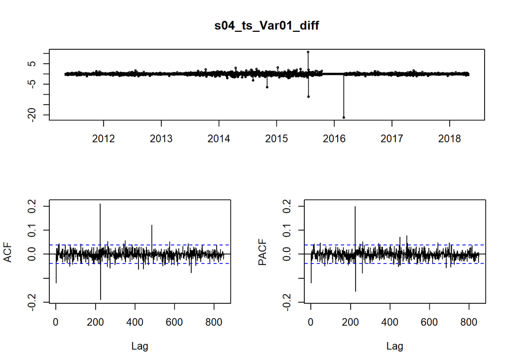

```r
# S04: Var01 & Var02

par(mfrow = c(1, 2))

s04_ts_Var01_diff <- diff(s04_ts[,1])
s04_ts_Var02_diff <- diff(s04_ts[,2])

tsdisplay(s04_ts_Var01_diff)
```

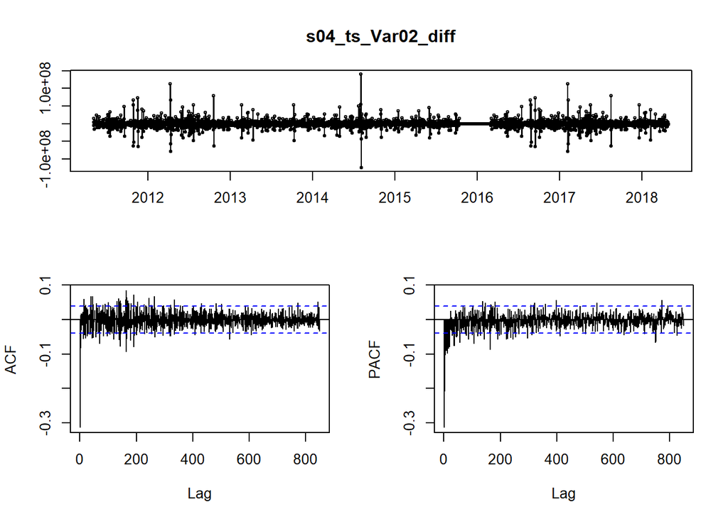

```r
tsdisplay(s04_ts_Var02_diff)
```

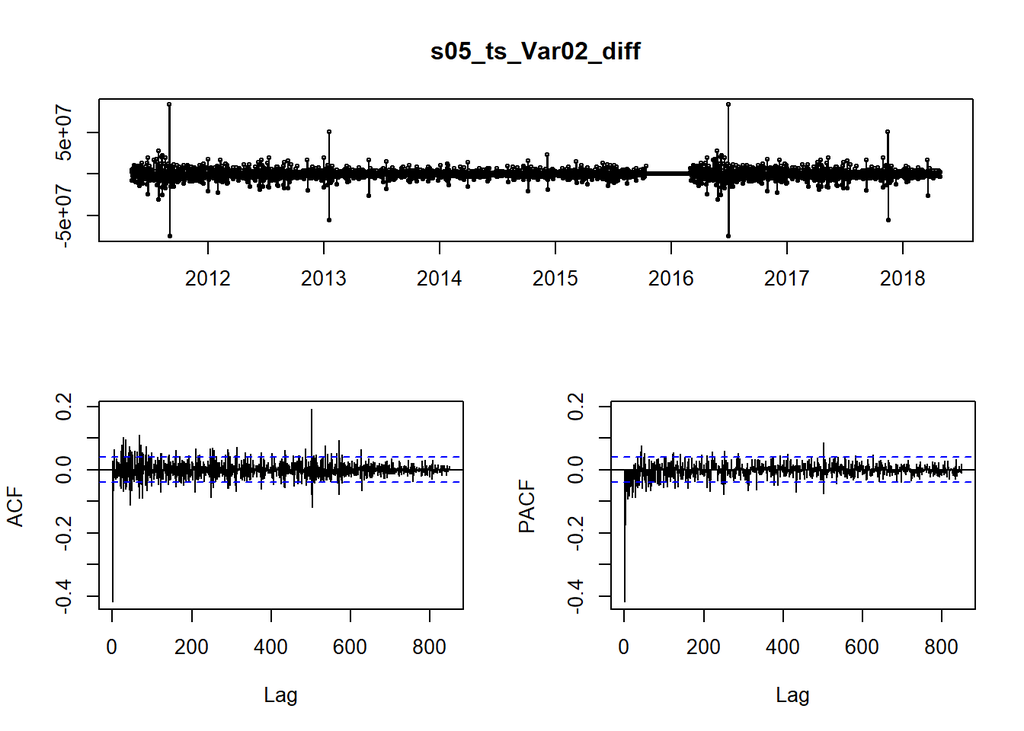

```r
# S05: Var02 & Var03

par(mfrow = c(1, 2))

s05_ts_Var02_diff <- diff(s05_ts[,1])
s05_ts_Var03_diff <- diff(s05_ts[,2])

tsdisplay(s05_ts_Var02_diff)
```

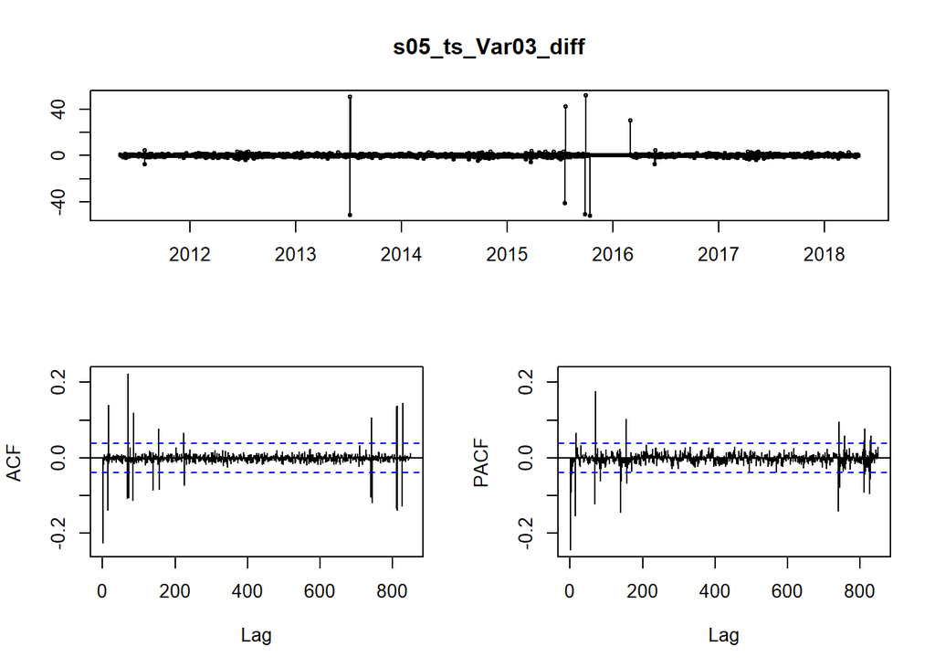

```r
tsdisplay(s05_ts_Var03_diff)
```

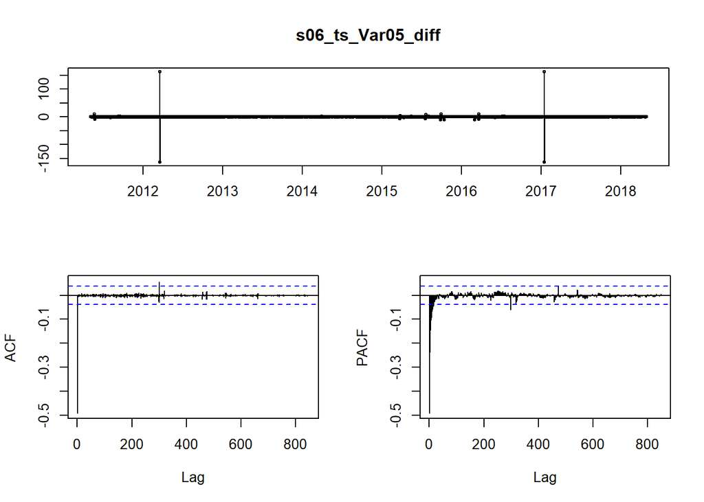

```r
# S06: Var05 & Var07

par(mfrow = c(1, 2))

s06_ts_Var05_diff <- diff(s06_ts[,1])
s06_ts_Var07_diff <- diff(s06_ts[,2])

tsdisplay(s06_ts_Var05_diff)
```

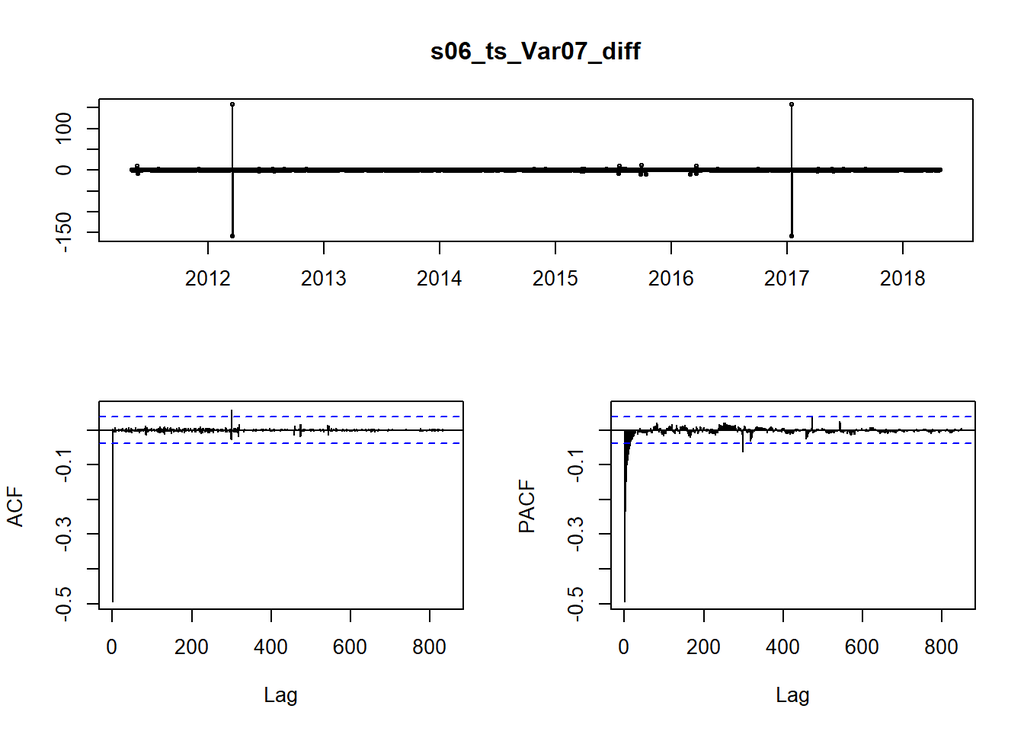

```r
tsdisplay(s06_ts_Var07_diff)
```

## Modeling

### ARIMA

Because the data is skewed, we will use Box-Cox transformation to normalize the data when trying to fit an ARIMA model to the data.

```r
# S01: Var01 & Var02

s01_Var01_lambda <- BoxCox.lambda(s01_ts[,1])

fit_ARIMA_s01_Var01 <- auto.arima(s01_ts[,1], seasonal = TRUE, stepwise = TRUE, lambda = s01_Var01_lambda)

fc_ARIMA_s01_Var01 <- forecast(fit_ARIMA_s01_Var01)

summary(fit_ARIMA_s01_Var01)
```

```
#> Series: s01_ts[, 1]
#> ARIMA(2,1,0)
#> Box Cox transformation: lambda= -0.9999242
#>
#> Coefficients:
#>          ar1      ar2
#>       0.0618  -0.0721
#> s.e.  0.0198   0.0198
#>
#> sigma^2 = 2.915e-07:  log likelihood = 15570.76
#> AIC=-31135.52   AICc=-31135.51   BIC=-31117.99
#>
#> Training set error measures:
#>                       ME      RMSE       MAE         MPE      MAPE       MASE
#> Training set 0.002928109 0.7906789 0.3393561 -0.01029034 0.9629324 0.03274866
#>                      ACF1
#> Training set -0.009934541
```

```r
s01_Var02_lambda <- BoxCox.lambda(s01_ts[,2])

fit_ARIMA_s01_Var02 <- auto.arima(s01_ts[,2], seasonal = TRUE, stepwise = TRUE, lambda = s01_Var02_lambda)

fc_ARIMA_s01_Var02 <- forecast(fit_ARIMA_s01_Var02)

summary(fit_ARIMA_s01_Var02)
```

```
#> Series: s01_ts[, 2]
#> ARIMA(5,1,1)
#> Box Cox transformation: lambda= 0.01787624
#>
#> Coefficients:
#>          ar1     ar2     ar3      ar4     ar5      ma1
#>       0.4453  0.0773  0.0577  -0.0052  0.0635  -0.9568
#> s.e.  0.0228  0.0224  0.0223   0.0222  0.0212   0.0109
#>
#> sigma^2 = 0.1669:  log likelihood = -1332.9
#> AIC=2679.8   AICc=2679.84   BIC=2720.71
#>
#> Training set error measures:
#>                  ME    RMSE     MAE       MPE     MAPE      MASE       ACF1
#> Training set 375699 3465962 2218662 -4.976253 23.31544 0.3697557 -0.0116913
```

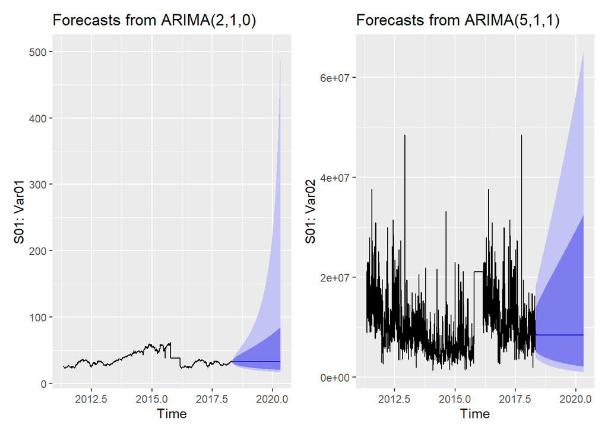

```r
#plot forecast
f1 <- autoplot(fc_ARIMA_s01_Var01) + ylab("S01: Var01")
f2 <- autoplot(fc_ARIMA_s01_Var02) + ylab("S01: Var02")
(f1 + f2)
```